# Human Activity Recognition: Practical Machine Learning

## Introduction

Using devices such as Jawbone Up, Nike FuelBand, and Fitbit it is now possible to collect a large amount of data about personal activity relatively inexpensively. These type of devices are part of the quantified self movement - a group of enthusiasts who take measurements about themselves regularly to improve their health, to find patterns in their behavior, or because they are tech geeks. One thing that people regularly do is quantify how much of a particular activity they do, but they rarely quantify how well they do it.

The goal is to use data from accelerometers placed on the belt, forearm, arm, and dumbell of 6 participants to to predict the manner in which they did the exercise based on traning data and testing data.

## Data Sources

The training data for this project are available here:

https://d396qusza40orc.cloudfront.net/predmachlearn/pml-training.csv

The test data are available here:

https://d396qusza40orc.cloudfront.net/predmachlearn/pml-testing.csv

The data for this project comes from this original source: http://groupware.les.inf.puc-rio.br/har

## Code Begin

Loading the appropriate packages.Make sure you have these installed before the code could function

```r
library(caret)
```

```r
library(corrplot)
library(kernlab)
library(knitr)
library(randomForest)
library(rattle)
library(RColorBrewer)
```

### Getting and Cleaning data for the Model

Two csv files contatining the training and test data was downloaded from Amazon’s cloudfront on the 24/08/2014 into a data folder in the working directory.

```r
# check if a data folder exists; if not then create one
#if (!file.exists("data")) {dir.create("data")}
```

Downloading csv file and loading in from the local directory. Make sure you have a data folder in your code path

```r
# fileUrl1 <- "https://d396qusza40orc.cloudfront.net/predmachlearn/pml-training.csv"
# destfile1 <- "./data/pml-training.csv"
# fileUrl2 <- "https://d396qusza40orc.cloudfront.net/predmachlearn/pml-testing.csv"
# destfile2 <- "./data/pml-testing.csv"

# dowload data
# download.file(fileUrl1, destfile = destfile1)
# download.file(fileUrl2, destfile = destfile2)
#
#read csv and removing Na and #DIV/0 fields
set.train <- read.csv(file = './data/pml-training.csv',na.strings = c('NA','#DIV/0!',''))
set.test <- read.csv(file = './data/pml-testing.csv',na.strings = c('NA','#DIV/0!',''))

#removing first 7 columns and redundnat columns
set.train.clean <- set.train[8:length(set.train)]

set.train.clean = set.train.clean[colnames(set.train.clean[colSums(is.na(set.train.clean)) == 0])]
```

### Model

Slicing the training data set into two data sets: 80% for training, 20% for testing:

```r
# split the cleaned testing data into training and cross validation
inTrain <- createDataPartition(y = set.train.clean$classe, p = 0.8, list = FALSE)
training <- set.train.clean[inTrain, ]
testing.val <- set.train.clean[-inTrain, ]
```

#### Data inspection

We are using a Random forest classification method to predict the classification because RF models have low variance and low bias without worrying much about how they are tuned.

Ease of use and quality of prediction are others why I have preferred random forest over other methods

```r
# fit a model to predict the classe using everything else as a predictor
 model.rf <- train(classe ~ ., data = training,
                   method = 'rf',trControl = trainControl(method = "cv",
                                                          number = 4,
                                                          allowParallel = TRUE,
                                                          verboseIter = TRUE))
pred.rf <- predict(model.rf,testing.val)
```

### Cross-validation

The model was then used to classify the remaining 20% of data. The results were placed in a confusion matrix along with the actual classifications in order to determine the accuracy of the model.

```r
# crossvalidate the model using the remaining 30% of data
predictCrossVal <- predict(model.rf, testing.val)
confusionMatrix(testing.val$classe, predictCrossVal)
```

```
## Confusion Matrix and Statistics
##
##           Reference
## Prediction    A    B    C    D    E
##          A 1116    0    0    0    0
##          B    2  757    0    0    0
##          C    0    2  681    1    0
##          D    0    0    1  642    0
##          E    0    0    0    0  721
##
## Overall Statistics
##
##                Accuracy : 0.998
##                  95% CI : (0.997, 0.999)
##     No Information Rate : 0.285
##     P-Value [Acc > NIR] : <2e-16
##
##                   Kappa : 0.998
##  Mcnemar's Test P-Value : NA
##
## Statistics by Class:
##
##                      Class: A Class: B Class: C Class: D Class: E
## Sensitivity             0.998    0.997    0.999    0.998    1.000
## Specificity             1.000    0.999    0.999    1.000    1.000
## Pos Pred Value          1.000    0.997    0.996    0.998    1.000
## Neg Pred Value          0.999    0.999    1.000    1.000    1.000
## Prevalence              0.285    0.193    0.174    0.164    0.184
## Detection Rate          0.284    0.193    0.174    0.164    0.184
## Detection Prevalence    0.284    0.193    0.174    0.164    0.184
## Balanced Accuracy       0.999    0.998    0.999    0.999    1.000
```

```r
#data set of model predictions on training data vs. actual observations
results.OO <- data.frame(pred = predict(model.rf, testing.val),
                         obs = testing.val$classe)
table(results.OO)
```

```
##     obs
## pred    A    B    C    D    E
##    A 1116    2    0    0    0
##    B    0  757    2    0    0
##    C    0    0  681    1    0
##    D    0    0    1  642    0
##    E    0    0    0    0  721
```

Same result can be plotted using ggplot. This plot demonstrate the classfication errors happened at pointed of overlap between classe types.

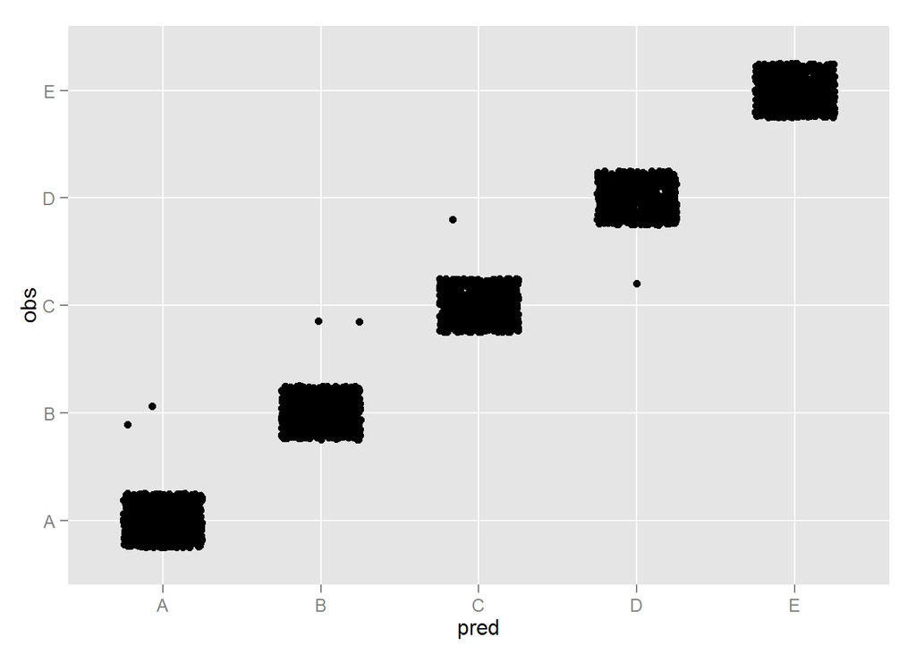

```r
p <- ggplot(results.OO, aes(x = pred, y = obs))
p <- p + geom_jitter(position = position_jitter(width = 0.25, height = 0.25))
p
```

### Predictions

```r
# Applying model to the testing data
new.data.test <- read.csv("./data/pml-testing.csv", na.strings = c('NA','#DIV/0!',''))
new.data.test.clean <- new.data.test[8:length(new.data.test)]
new.data.test.clean = new.data.test.clean[colnames(new.data.test.clean[colSums(is.na(new.data.test.clean)) == 0])]
# predict the classes of the test set
predictTest <- predict(model.rf, new.data.test.clean)
predictTest
```

```
##  [1] B A B A A E D B A A B C B A E E A B B B
## Levels: A B C D E
```

### Conclusion

Here we have built a randomforest model to classify a person’s quality of excerise using multitudes of data collected from health activities. Model has a very good accuracy and low Out of sample error. Model has been applied to test set and also to a seperate set for the part2 of the project.